# SiSyn - Data Inventory

**FROM POLES TO TROPICS: A MULTI-BIOME SYNTHESIS INVESTIGATING THE CONTROLS ON RIVER SI EXPORTS**

[Project Overview](https://lternet.edu/working-groups/river-si-exports/)

## Spatial Distribution of Sites

[interactive chart not shown]

Monitoring locations of available data to date 2022-06-29.

## Period of Record Data Inventory

The following plots provide a graphical depiction of data on the Data set level (i.e. Bonanza LTER, Lamprey River, etc.).

## Arctic Great Rivers

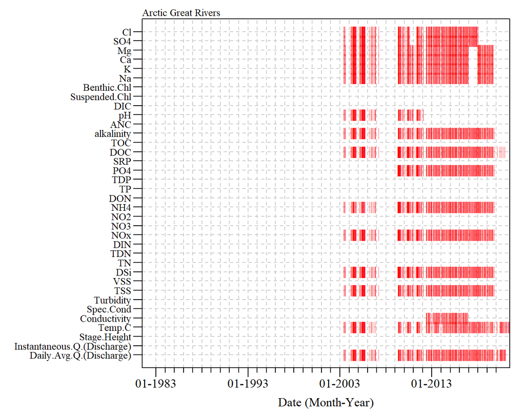

Arctic Great Rivers period of record parameter inventory for all sites.

## Arctic LTER

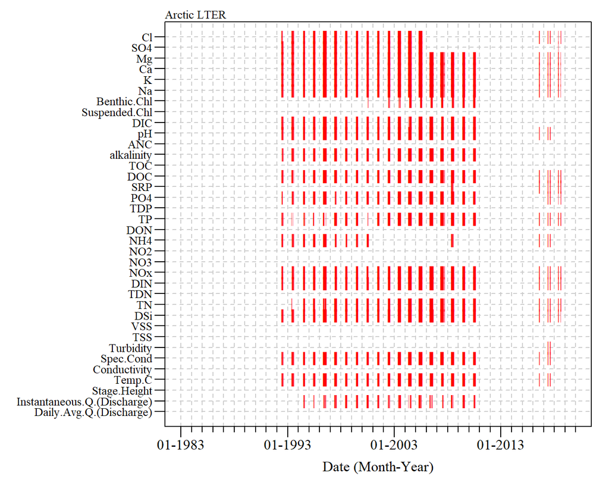

Arctic LTER period of record parameter inventory for all sites.

## Bonanza LTER

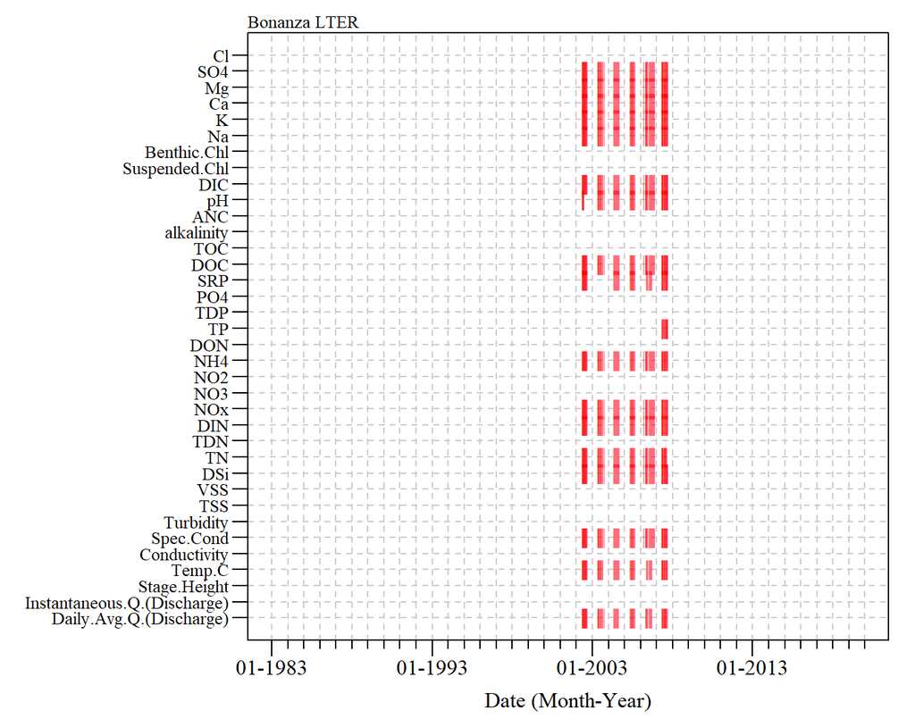

Bonanza LTER period of record parameter inventory for all sites.

## H.J. Andrews LTER

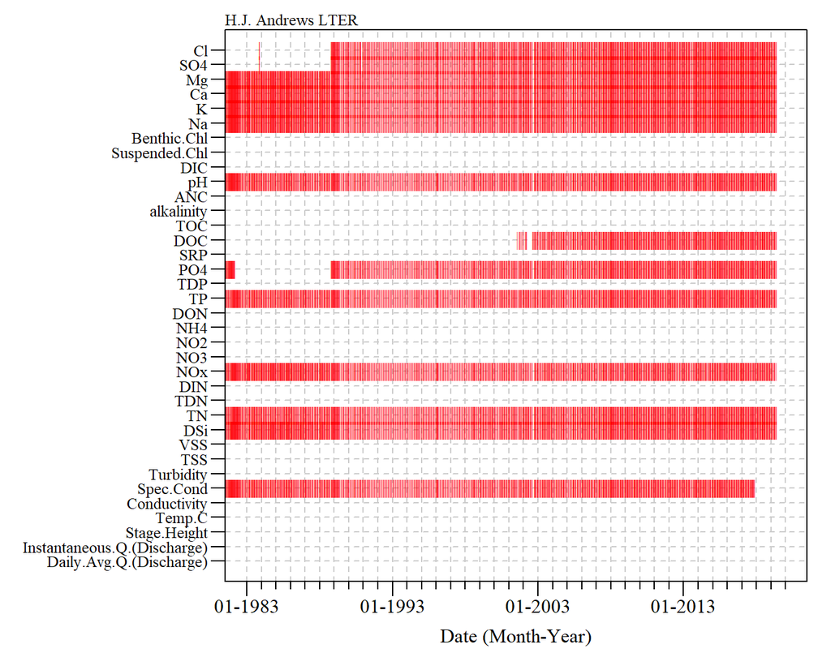

H.J. Andrews LTER period of record parameter inventory for all sites.

## Sagehen Creek

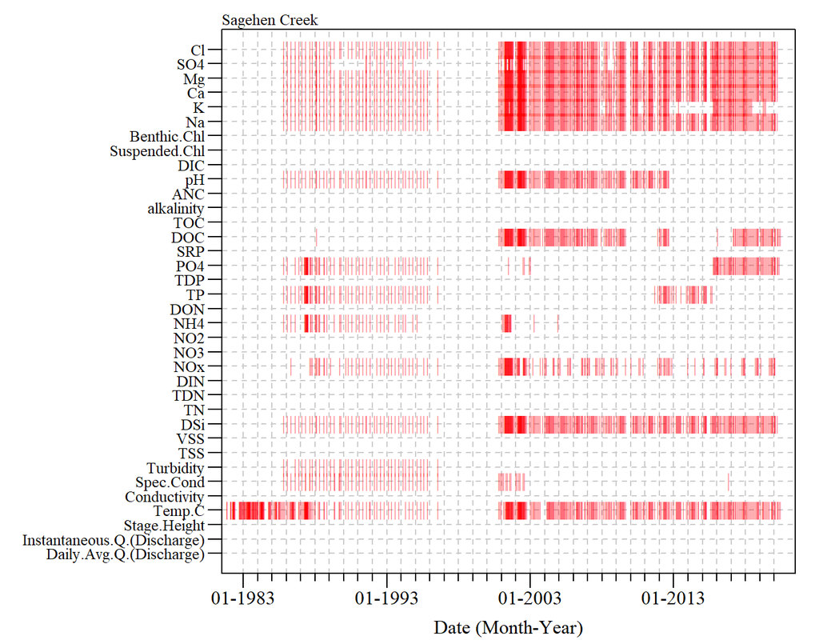

Sagehen Creek period of record parameter inventory for all sites.

## Boulder CZO

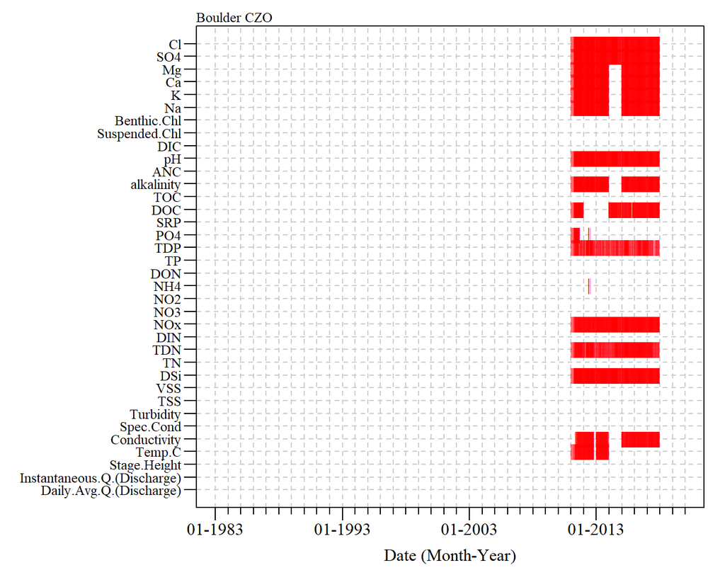

Boulder CZO period of record parameter inventory for all sites.

## Niwot Ridge LTER

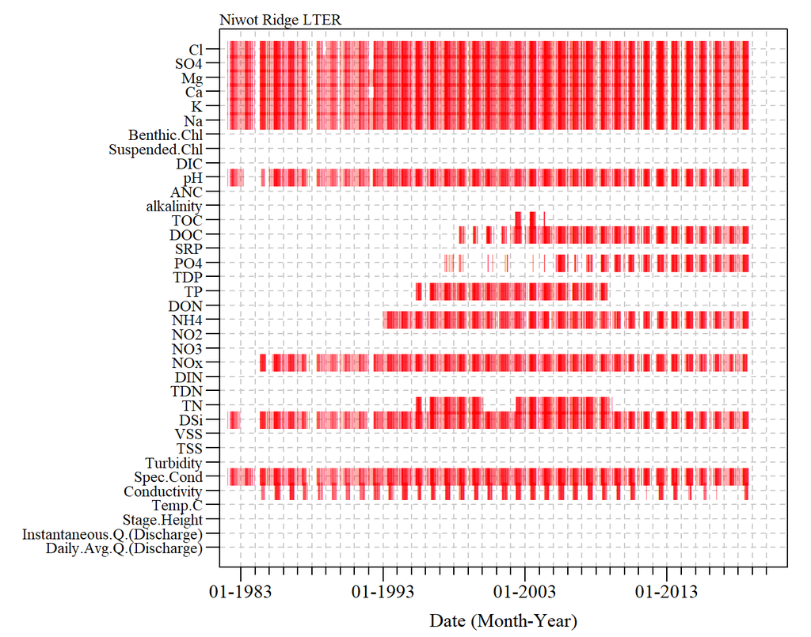

Niwot Ridge LTER period of record parameter inventory for all sites.

## East River SFA

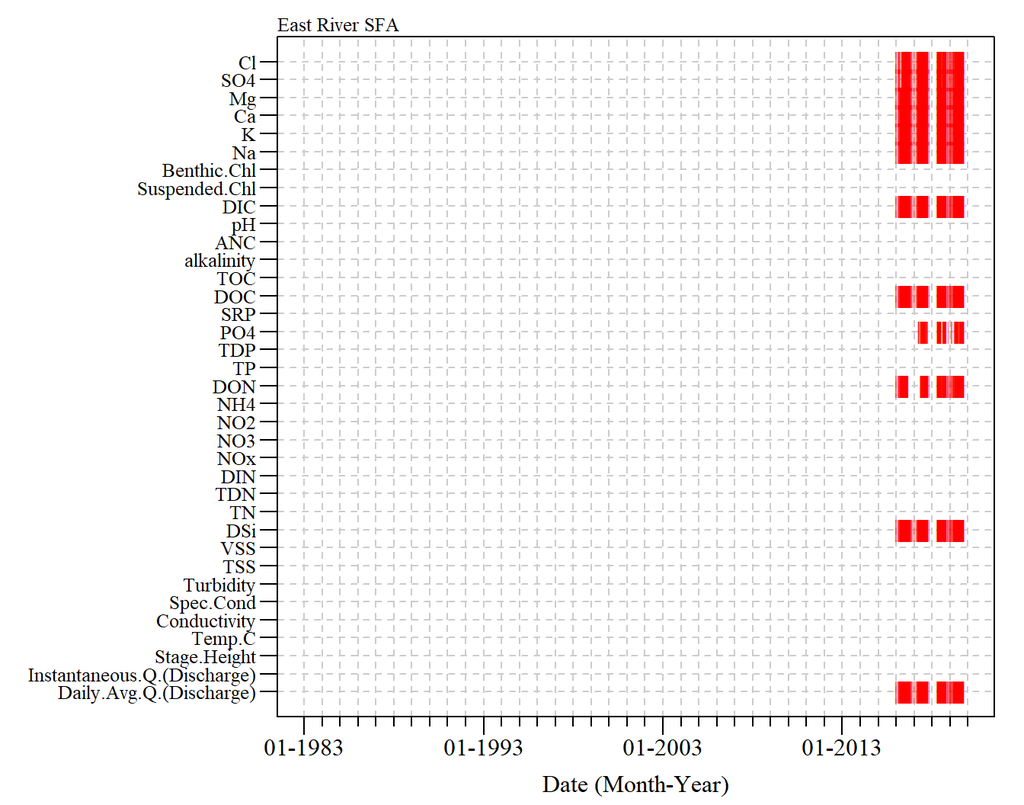

East River SFA period of record parameter inventory for all sites.

## Konza Prairie LTER

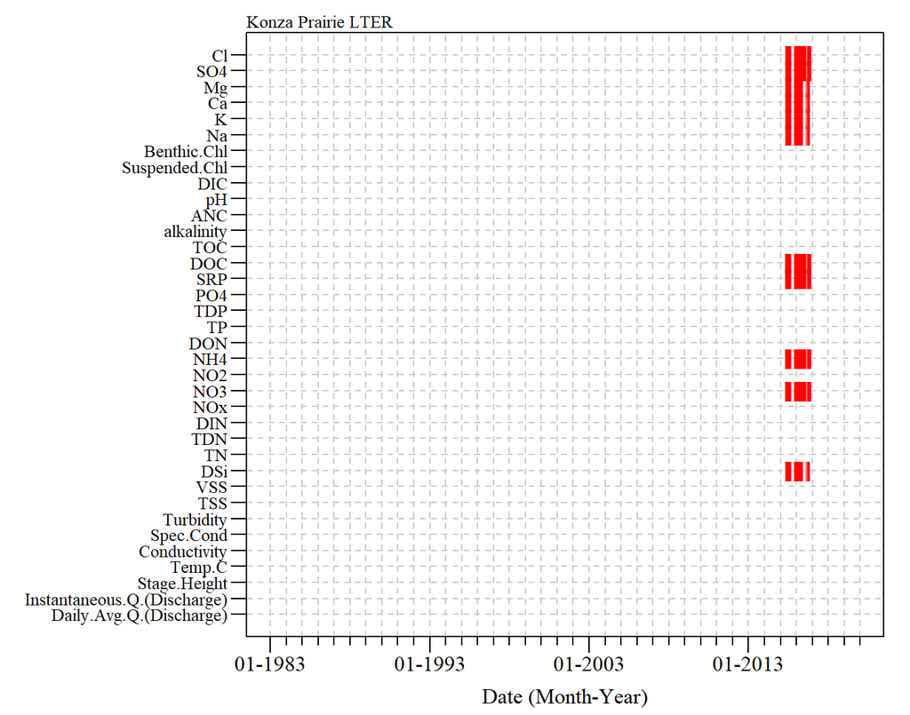

Konza Prairie LTER period of record parameter inventory for all sites.

## Lamprey River

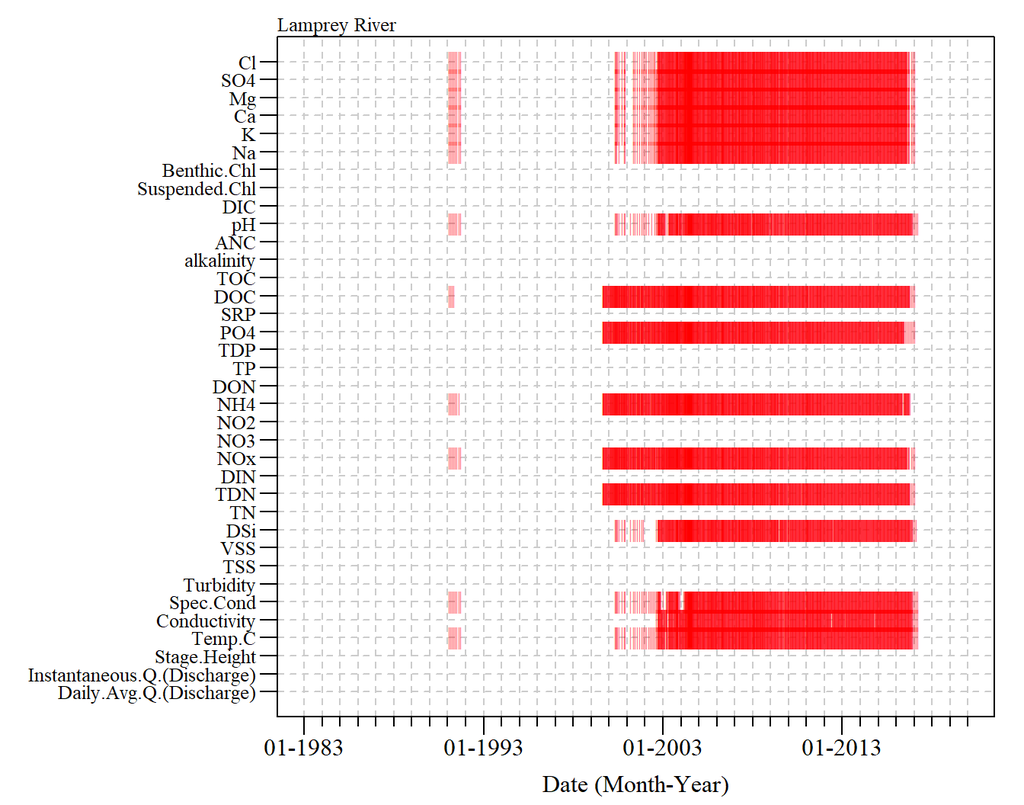

Lamprey River period of record parameter inventory for all sites.

## Plum Island Estuary LTER

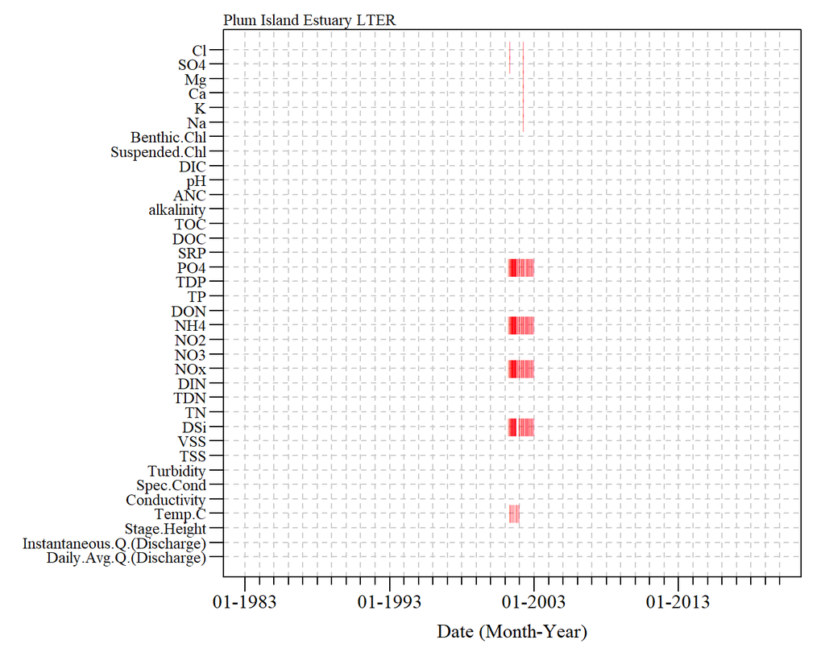

Plum Island Estuary LTER period of record parameter inventory for all sites.

## Hubbard Brook LTER

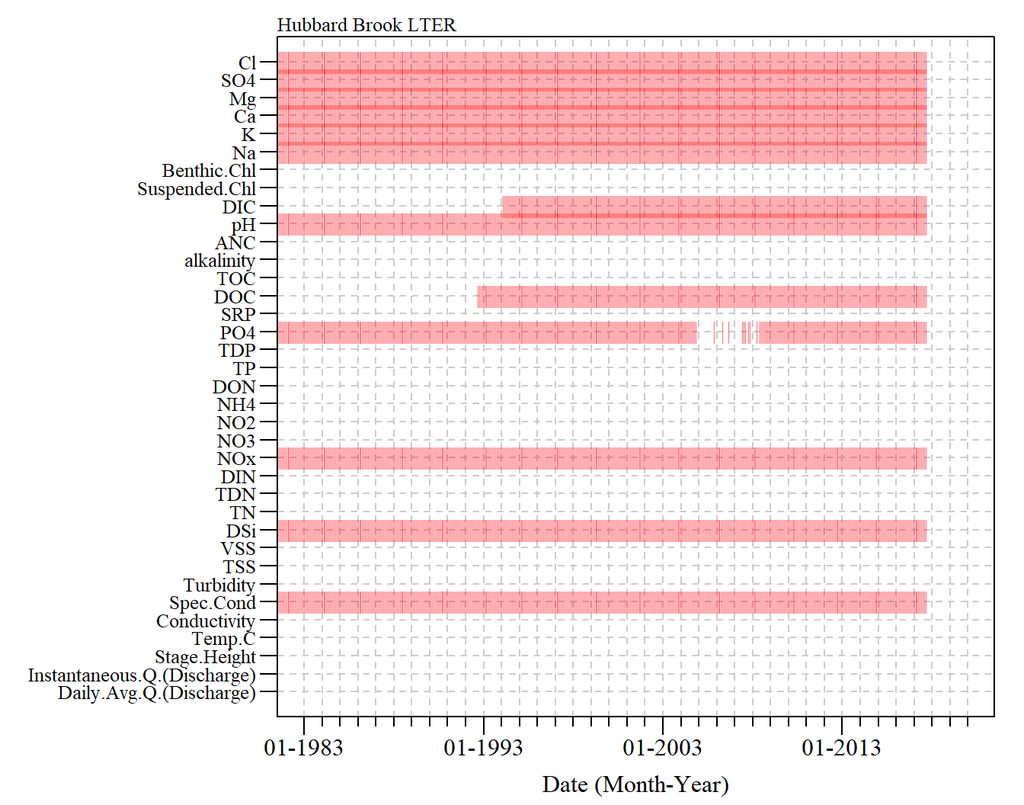

Hubbard Brook LTER period of record parameter inventory for all sites.

## Ispwich

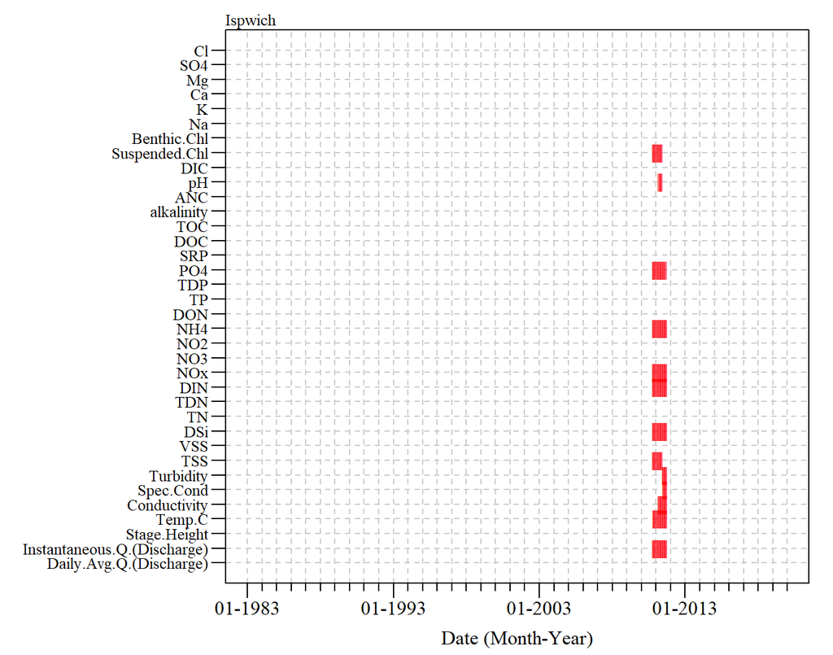

Ispwich period of record parameter inventory for all sites.

## Upper Mississippi River

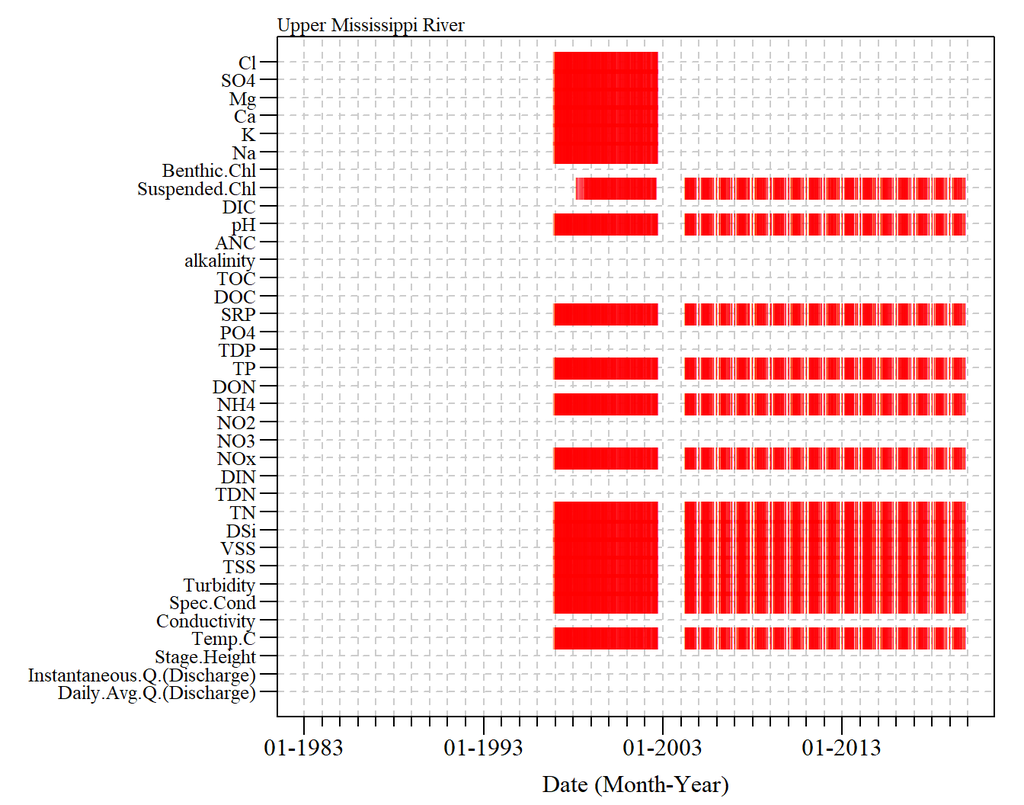

Upper Mississippi River period of record parameter inventory for all sites.

## Kissimmee River

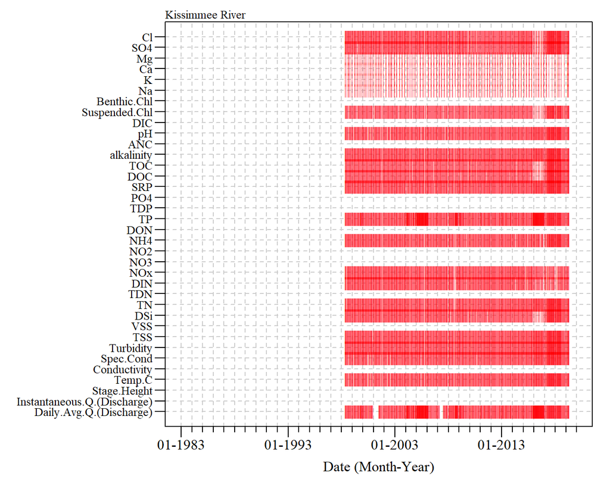

Kissimmee River period of record parameter inventory for all sites.

## Luquillo LTER

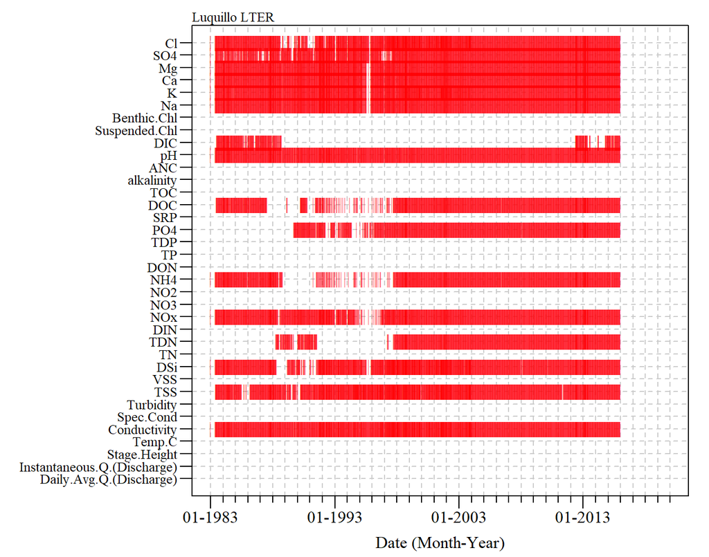

Luquillo LTER period of record parameter inventory for all sites.

## Tanguro

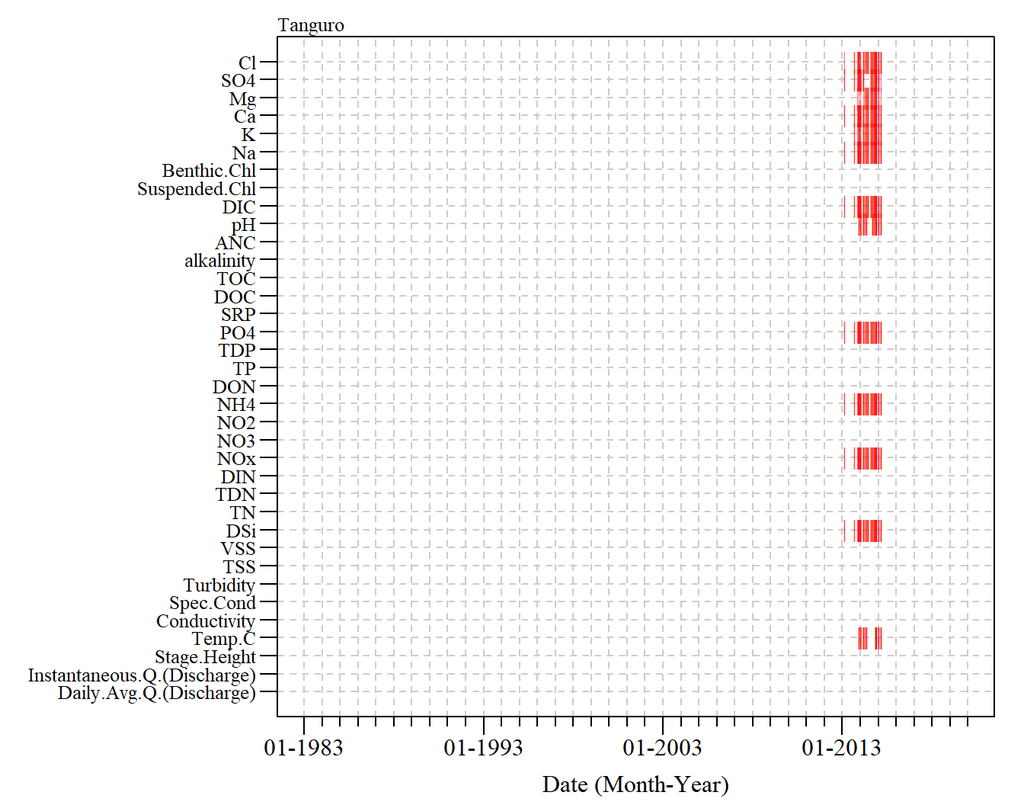

Tanguro period of record parameter inventory for all sites.

## MCM

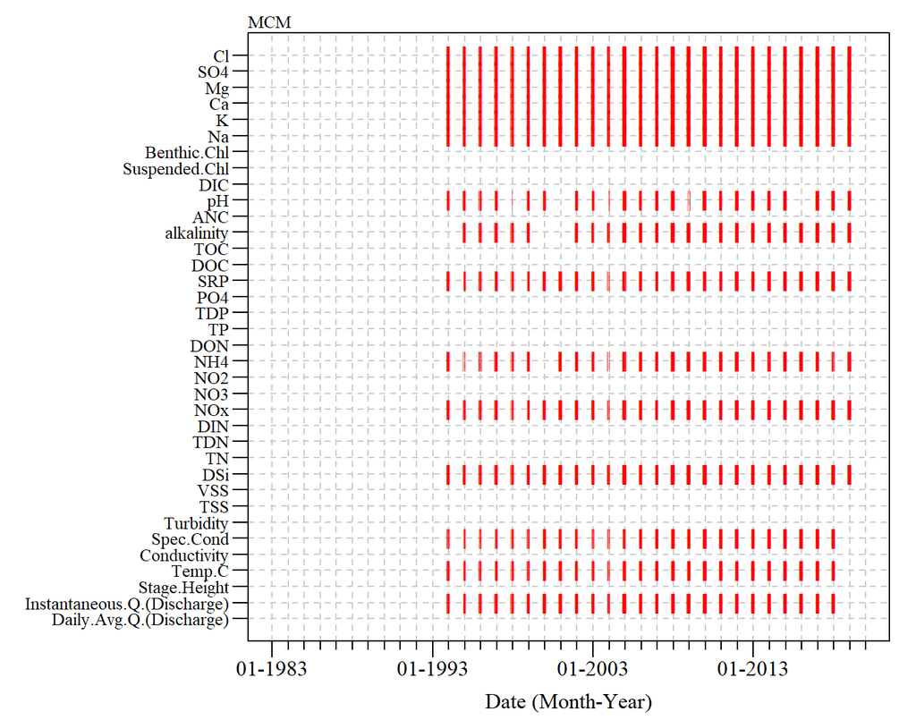

MCM period of record parameter inventory for all sites.

Updated 29 Jun 2022

Code hosted at [GitHub](https://github.com/SwampThingPaul/SiSyn)